# Day 31 - YOLO 目标检测

> 目标: 理解目标检测的核心思想, 跑通 YOLO demo

> YOLO = You Only Look Once — 一次前向就能检测所有物体

## 目标检测 vs 图像分类

```
图像分类:      这张图里有猫 (一个标签)
目标检测:      猫在哪? (位置 + 类别)
实例分割:      猫的每个像素 (精确轮廓)

YOLO 的核心:
  把图像分成 S×S 的网格
  每个网格负责检测中心落在它里面的物体
  一次前向同时预测所有框 + 类别
```

```
========================================
Day 31 - YOLO Object Detection
========================================
```

## 1. 核心思想: 网格 + 锚框

> 把图像分成网格, 每个网格预测 B 个锚框

> 每个锚框输出: x, y, w, h, confidence, class_probs

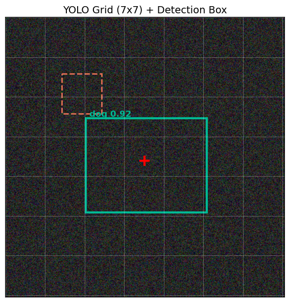

```
每个网格预测 B 个锚框
每个框输出: (x, y, w, h, confidence, class1_prob, class2_prob, ...)
```

## 2. 手写 NMS (非极大值抑制)

> YOLO 会预测很多重叠框, NMS 去掉冗余的

> 步骤: 选置信度最高的框 → 去掉跟它 IoU 高的 → 重复

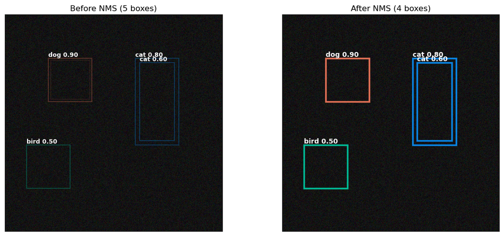

[output not shown]

## 3. 用预训练 YOLO 做检测

> 用 HuggingFace 的 YOLOS (轻量版 YOLO)

```
YOLO 检测流程:
1. 图像 -> SxS 网格 (如 7x7)
2. 每个网格预测 B 个锚框 (如 2 个)
3. 每个框输出: (x, y, w, h, confidence, C1, C2, ..., C80)
4. 过滤低置信度框
5. NMS 去掉重叠框
6. 输出最终检测结果

YOLOv8 可以直接用 pip 安装体验:
  pip install ultralytics
  yolo predict model=yolov8n.pt source=image.jpg
```

```
YOLO 输出形状: (1, 7, 7, 50)
  = batch=1, grid=7x7, B=2, (5 coord + 20 class)

每个网格单元预测:
  2 个框 × (x, y, w, h, conf, class_probs)
  = 2 × (5 + 20) = 50 个值
```

## 4. YOLO 发展史

> YOLO 从 v1 到 v8, 速度越来越快, 精度越来越高

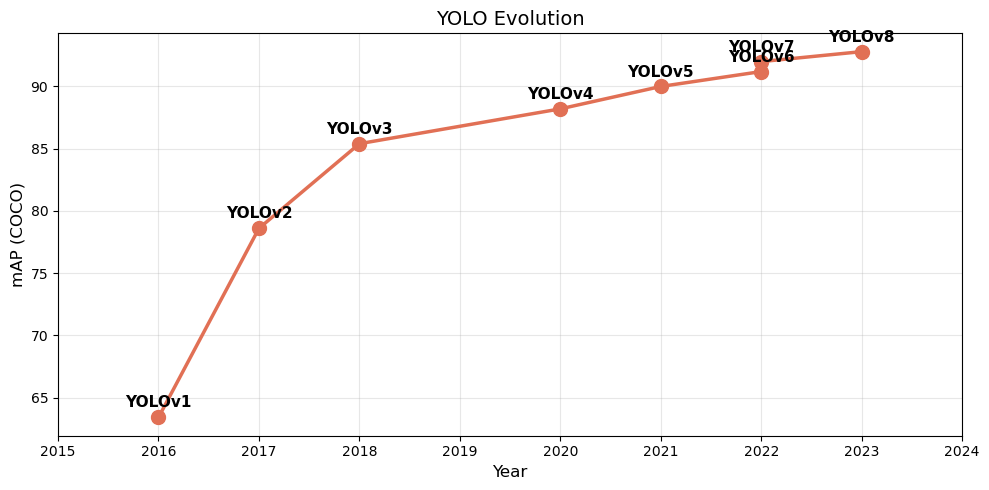

```
  YOLO v1    (2016) mAP=63.4
  YOLO v2    (2017) mAP=78.6
  YOLO v3    (2018) mAP=85.4
  YOLO v4    (2020) mAP=88.2
  YOLO v5    (2021) mAP=90.0
  YOLO v6    (2022) mAP=91.2
  YOLO v7    (2022) mAP=92.0
  YOLO v8    (2023) mAP=92.8
```

# Day 31 完成!

## 总结

| 概念 | 一句话 |
| --- | --- |
| **YOLO** | 一次前向检测所有物体, S×S 网格 + 锚框 |
| **NMS** | 非极大值抑制, 去掉重叠的多余框 |
| **IoU** | 交集/并集, 衡量两个框的重叠程度 |
| **锚框** | 预定义的形状模板, 预测偏移量 |
| **Faster R-CNN** | 两阶段检测器 (区域提议 + 分类) |

## 目标检测 vs 其他任务

```
分类:    这张图是猫
分类+定位: 这张图是猫, 在(100,100,200,200)
目标检测: 图里有猫(100,100,200,200), 狗(300,300,400,400)
实例分割: 猫的每个像素被标出来
全景分割: 整张图每个像素都有类别
```

## 剩余内容

| Day | 内容 |
| --- | --- |
| 32 | ONNX 模型部署 |
| 33 | 整理 GitHub + 技术博客 |
| 34 | 方向选择 (CV/NLP/多模态/RL) |
| 35 | 最终总结 + 知识地图 |

## 作业 (2 题)

### 1. 改 NMS 阈值

**位置:** cell-5, `nms(boxes, scores, iou_thresh=0.5)`

改成 0.1 (严格) 和 0.9 (宽松), 保留的框数量怎么变?

**📖 答案**

thresh=0.1: 几乎重叠就删, 保留框少 (可能漏检) thresh=0.9: 几乎完全重叠才删, 保留框多 (可能有冗余) YOLO 默认用 0.5-0.7

### 2. 理解置信度阈值

**位置:** cell-8, `score_thresh = 0.7`

改成 0.3 和 0.9, 检测数量变化?

**📖 答案**

thresh=0.3: 更多检测结果 (可能有误检) thresh=0.9: 很少检测结果 (可能漏检) 实际使用: 根据场景权衡 安全场景 (自动驾驶) → 低阈值, 宁可误检不能漏检 精度优先 (质检) → 高阈值, 宁可漏检不能误检